# Example without technical replicates

Jordi Camps

8 November 2017

Make sure you did all the previous steps explained in the README file. Install the qpcrviia7 package and the other required packages. Make sure your data file and annotation files are correct. You can use this example as a template to make your own script for analysis. Rmarkdown makes it possible to run the analysis in chunks to understand the individual steps better and can knit everything together in an html file.

# Load librararies

We first need to load the packages that we will use into our session. Make sure you’ve installed all packages before else you will get an error.

```r
knitr::opts_chunk$set(echo = TRUE)
library(qpcrviia7)
library(readxl)
library(dplyr)
library(tidyr)
library(ggplot2)
library(ggthemes)
library(RColorBrewer)
```

# Prepare files

## Import data

Data needs to be imported into the R session, we will use our own functions for this matter. read_qpcr() reads the raw excel file obtained from the Viia7 after qPCR and read_annotation reads our annotation files.

### Import raw data with read_qpcr()

```r
qpcr <- read_qpcr("Data/2017-09-20 124839 FAP-C2C12-Muscle qPCR validation MC.xls", sheet = 3)
```

```
## # A tibble: 368 x 8
##    Position_well    Sample   Target      CT CT_threshold      Tm1   Tm2
##            <chr>     <chr>    <chr>   <dbl>        <dbl>    <dbl> <dbl>
##  1            A1  Sample 1 Target 1 21.2551         0.04 79.13522    NA
##  2            A2  Sample 2 Target 1 18.9371         0.04 79.13522    NA
##  3            A3  Sample 3 Target 1 17.7691         0.04 79.13522    NA
##  4            A4  Sample 4 Target 1 17.9764         0.04 79.26957    NA
##  5            A5  Sample 5 Target 1 17.7402         0.04 79.26957    NA
##  6            A6  Sample 6 Target 1 18.0660         0.04 79.13522    NA
##  7            A7  Sample 7 Target 1 19.6004         0.04 79.26957    NA
##  8            A8  Sample 8 Target 1 18.6120         0.04 79.26957    NA
##  9            A9  Sample 9 Target 1 19.4874         0.04 79.26957    NA
## 10           A10 Sample 10 Target 1 19.1846         0.04 79.26957    NA
## # ... with 358 more rows, and 1 more variables: Tm3 <dbl>
```

### Import annotation with read_annotation()

```r
ann_samples <- read_annotation("Data/Annotations_124839_samples.xlsx")
```

```
## # A tibble: 24 x 6
##       Sample Blanc Cell_type  Condition    Mouse Passage
##        <chr> <chr>     <chr>      <chr>    <chr>   <dbl>
##  1  Sample 1     N        TA    healthy C57BL6-1      NA
##  2  Sample 2     N        TA    healthy C57BL6-2      NA
##  3  Sample 3     N        TA    healthy C57BL6-3      NA
##  4  Sample 4     N        TA    healthy C57BL6-4      NA
##  5  Sample 5     N        TA    healthy C57BL6-5      NA
##  6  Sample 6     N        TA    healthy C57BL6-6      NA
##  7  Sample 7     N        TA dystrophic    Sgca1      NA
##  8  Sample 8     N        TA dystrophic    Sgca3      NA
##  9  Sample 9     N        TA dystrophic    Sgca4      NA
## 10 Sample 10     N        TA dystrophic    Sgca5      NA
## # ... with 14 more rows
```

```r
ann_genes <- read_annotation("Data/Annotations_124839_primers.xlsx")
```

```
## # A tibble: 16 x 3
##       Target   Gene   HKG
##        <chr>  <chr> <chr>
##  1  Target 1  Psma3     Y
##  2  Target 2  Rab35     Y
##  3  Target 3 Rpl13a     Y
##  4  Target 4    Dcn     N
##  5  Target 5   GILZ     N
##  6  Target 6   Has1     N
##  7  Target 7  Thbs4     N
##  8  Target 8    Lum     N
##  9  Target 9  Plag1     N
## 10 Target 10  Erdr1     N
## 11 Target 11  Gdf10     N
## 12 Target 12  Meox2     N
## 13 Target 13  Sca-1     N
## 14 Target 14  Igf-1     N
## 15 Target 15  Myod1     N
## 16 Target 16  Myog1     N
```

## Merge and tidy files with join_and_clean_qpcr()

After loading in the files we can see that they are still untidy. We will merge all files into one big dataframe and change the undetermined values in the CT column to NA so that our data is ready for analysis.

```r
join_and_clean_qpcr(qpcr)
```

```
## # A tibble: 368 x 15
##    Position_well    Sample   Target      CT CT_threshold      Tm1   Tm2
##            <chr>    <fctr>   <fctr>   <dbl>        <dbl>    <dbl> <dbl>
##  1            A1  Sample 1 Target 1 21.2551         0.04 79.13522    NA
##  2            A2  Sample 2 Target 1 18.9371         0.04 79.13522    NA
##  3            A3  Sample 3 Target 1 17.7691         0.04 79.13522    NA
##  4            A4  Sample 4 Target 1 17.9764         0.04 79.26957    NA
##  5            A5  Sample 5 Target 1 17.7402         0.04 79.26957    NA
##  6            A6  Sample 6 Target 1 18.0660         0.04 79.13522    NA
##  7            A7  Sample 7 Target 1 19.6004         0.04 79.26957    NA
##  8            A8  Sample 8 Target 1 18.6120         0.04 79.26957    NA
##  9            A9  Sample 9 Target 1 19.4874         0.04 79.26957    NA
## 10           A10 Sample 10 Target 1 19.1846         0.04 79.26957    NA
## # ... with 358 more rows, and 8 more variables: Tm3 <dbl>, Blanc <fctr>,
## #   Cell_type <fctr>, Condition <fctr>, Mouse <fctr>, Passage <fctr>,
```

[output cut: 17 more lines]

# Quality control

## CT

To start we plot all CT values to check the distribution and spot eventual outliers

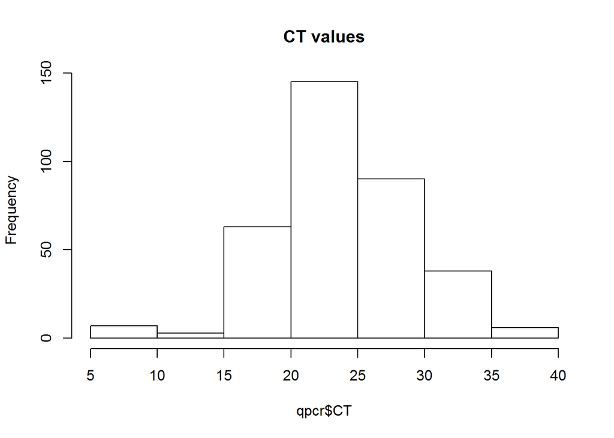

```r
par(mfrow=c(1,1))
hist(qpcr$CT, main = "CT values")
```

### Samples

We plot the CT values per Sample to check the distribution per Sample and to spot outliers. You should also be able to see the blanc sample or if the blanc was totally not contaminated you won’t be able to see it. Bad Samples can be removed with remove_sample(). Check the minimal level of CT values to select it later in the function set_min_max_CT(). The value of the blanc sample can be used to set the maximum level of CT.

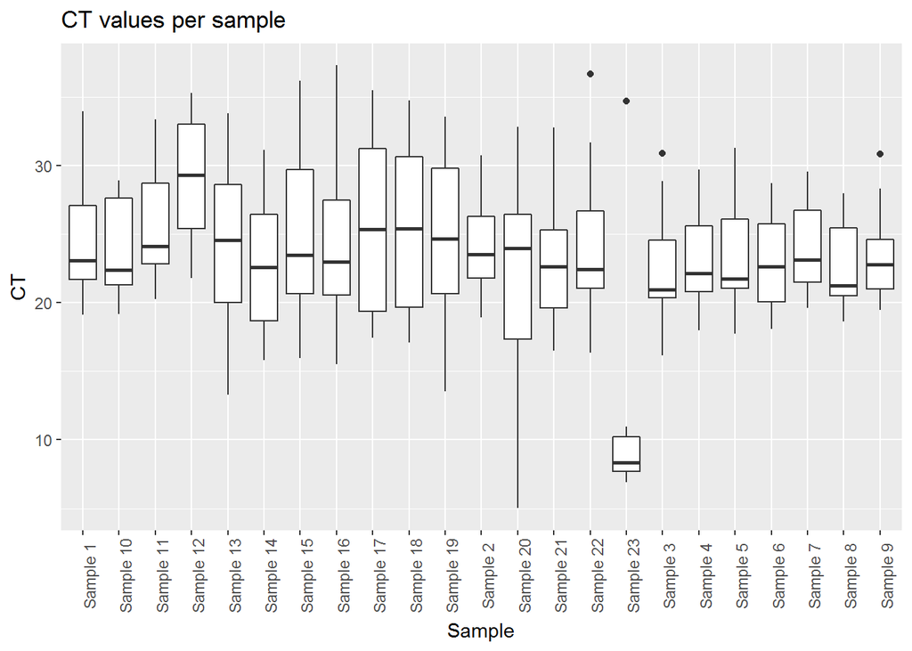

```r
ggplot(qpcr, aes(Sample, CT)) +
  geom_boxplot() +
  theme(axis.text.x = element_text(angle = 90)) +
  ggtitle("CT values per sample")
```

### Genes

We plot the CT values per Gene to check the distribution per Gene and to spot outliers. Bad Genes can be removed with remove_primer().

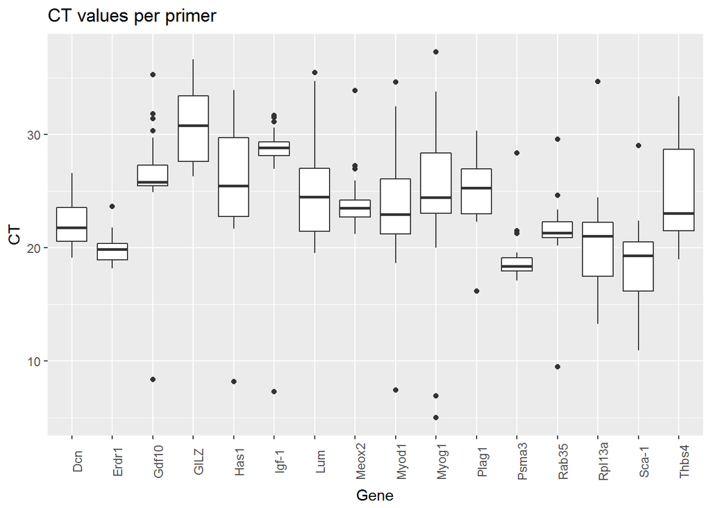

```r
ggplot(qpcr, aes(Gene, CT)) +
  geom_boxplot() +
  theme(axis.text.x = element_text(angle = 90)) +
  ggtitle("CT values per primer")
```

### Remove blanc sample with remove_blanc()

After we checked the blanc we don’t need it anymore in further analysis so it needs to be removed. We use the function remove_blanc() for this.

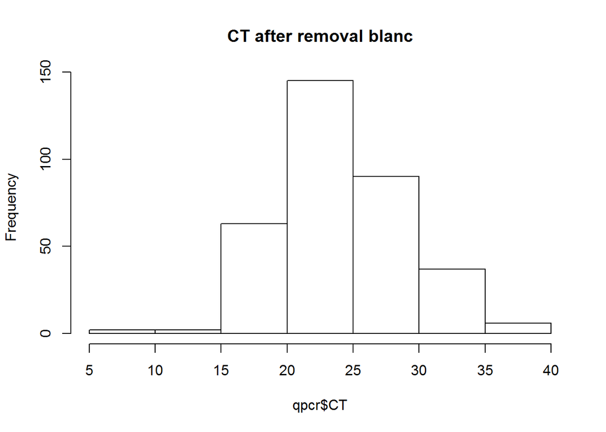

```r
qpcr <- remove_blanc(qpcr)
hist(qpcr$CT, main = "CT after removal blanc")
```

### Seperate endogenous from housekeeping genes with split_genes()

Now we need to seperate our data into a set of housekeeping genes and endogenous genes. Housekeeping genes will be saved in a dataframe called **hkg** and the endogenous genes in a dataframe called **endog**. We need to this to be able to run the qc_hkg() function on the housekeeping genes.

```r
split_genes(qpcr)
```

### Set base CT value with set_min_max_CT()

```r
endog <- set_min_max_CT(endog, 10, 40)
```

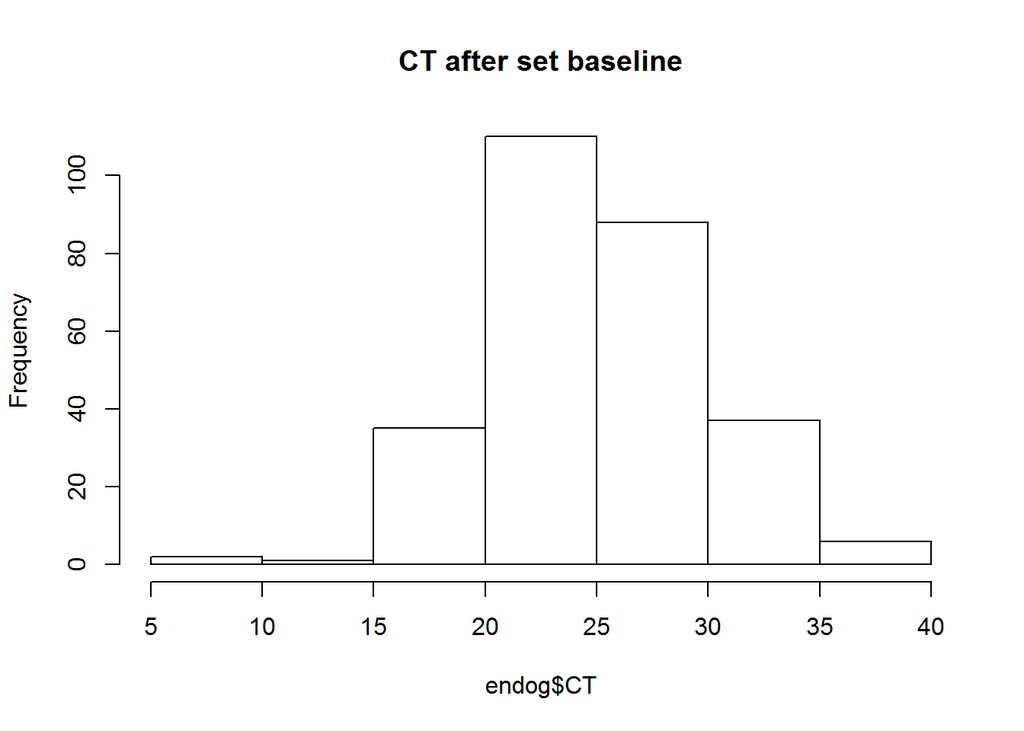

```r
hist(endog$CT, main = "CT after set baseline")
```

## Melt curve analysis

Print a list of all genes with double meltcurve peaks with list_double_meltcurves().

```r
list_double_meltcurves(endog)
```

```
## # A tibble: 7 x 3
##        CT      Tm1      Tm2
##     <dbl>    <dbl>    <dbl>
## 1 33.3840 91.49501 64.08852
## 2 36.1644 84.10601 80.88171
## 3 33.4903 91.62936 85.31512
## 4 35.3785 91.62936 85.44946
## 5 33.0620 91.62936 85.71815
## 6 33.5540 91.62936 87.33031
## 7 32.8323 91.62936 67.85020
```

Remove bad meltcurves with remove_bad_meltcurves().

```r
remove_bad_meltcurves()
```

## Housekeeping genes

### Quality control per housekeeping gene with qc_hkg()

Now we will perform some quality control measures on our housekeeping genes. We recommend to use three housekeeping genes that show stable expression accross samples. the qc_hkg() function will check the distrubtion of CT values between samples of all housekeeping genes seperately. Here, we can see if the variability of any of the housekeeping genes is too high.

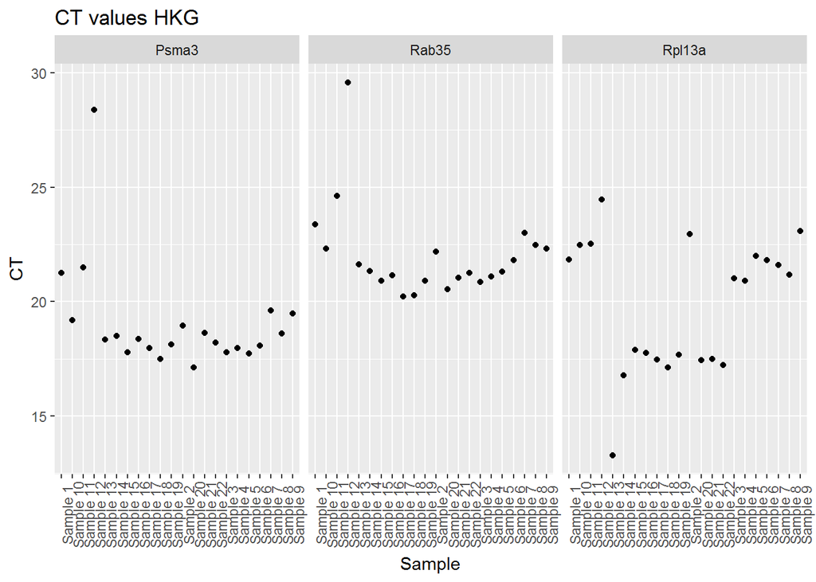

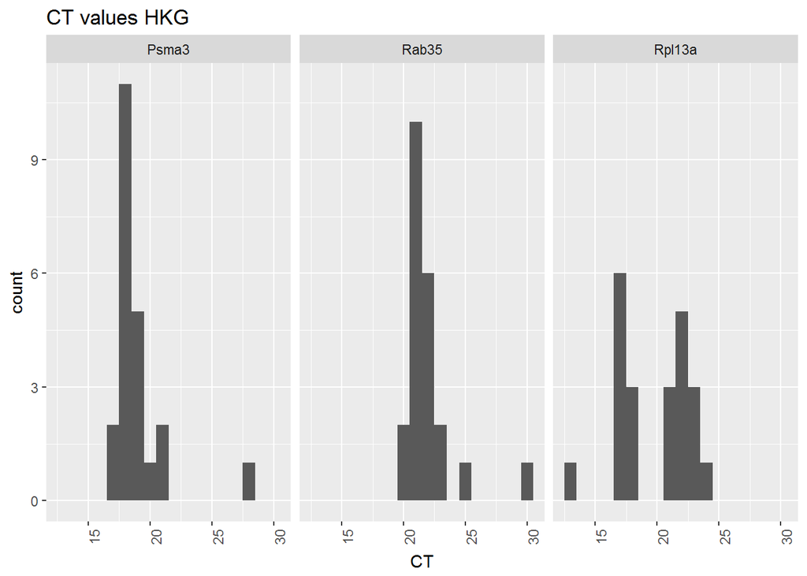

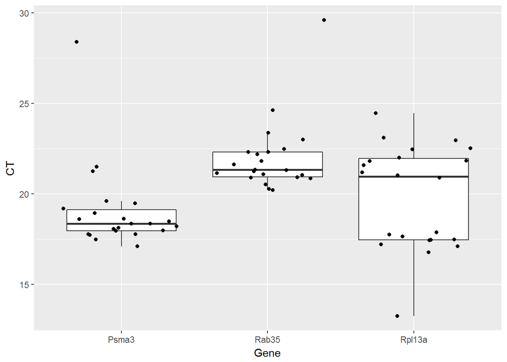

```r
qc_hkg(hkg)
```

### Remove irregular housekeeping genes with remove_primer()

In this example Rpl13a shows a binomial expression throughout the dataset. This is because we compare cell lines in vitro with skeletal muscle. Therefore, we remove this housekeeping gene with remove_primer().

```r
remove_primer(endog, "Rpl13a")
```

### Take geometric average over all housekeeping genes with calculate_mena_hkg()

When we assessed the quality of our housekeeping genes seperately it’s time to take the average of these genes.

```r
mean_hkg <- calculate_mean_hkg(hkg)
```

### Quality control over average of housekeeping genes with qc_mean_hkg()

After taking the average we plot quality control measures again to check for outliers.

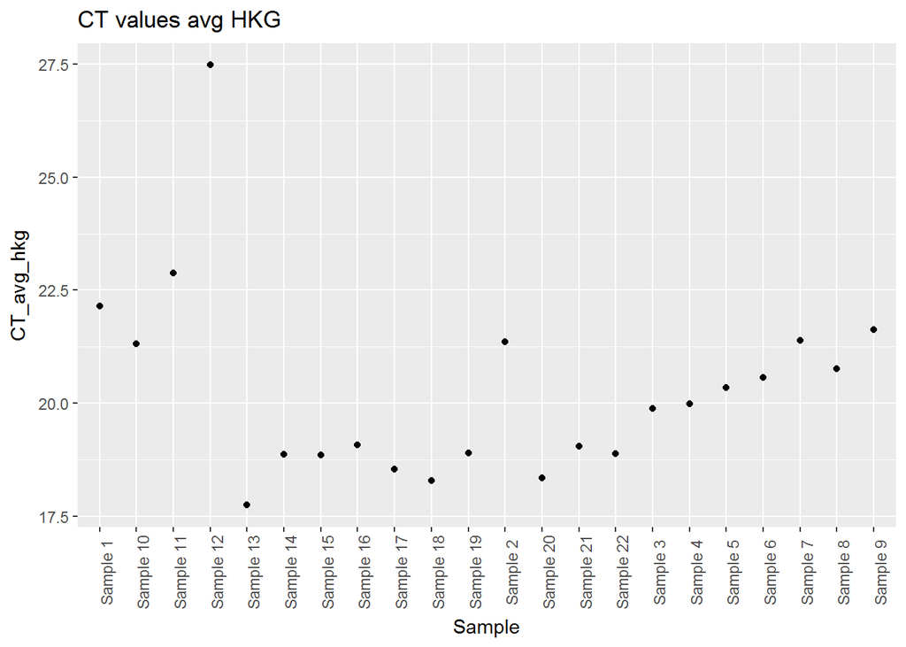

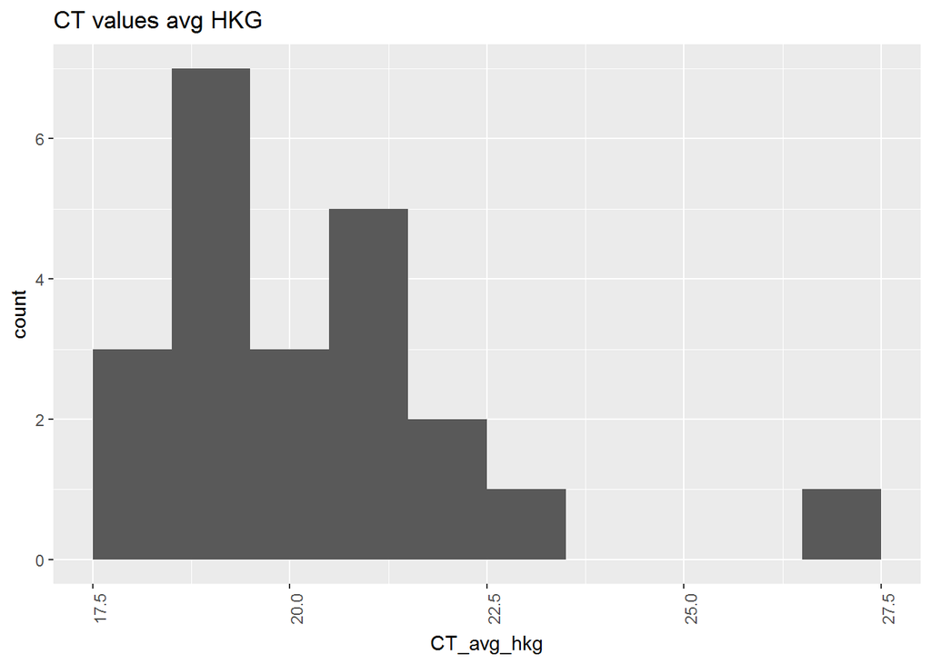

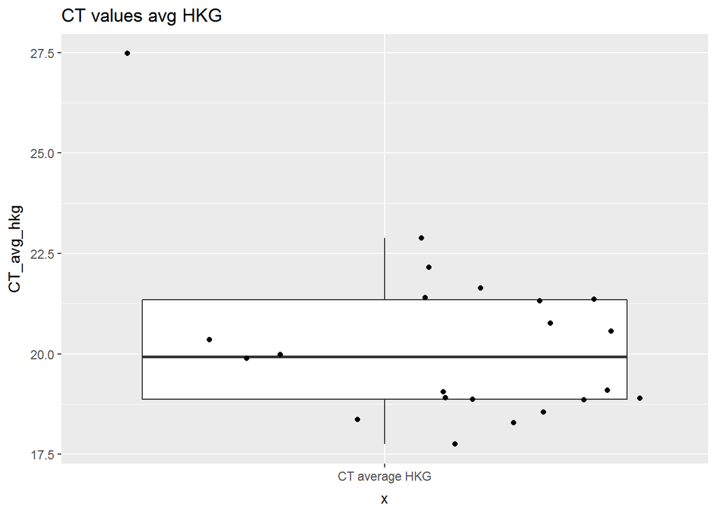

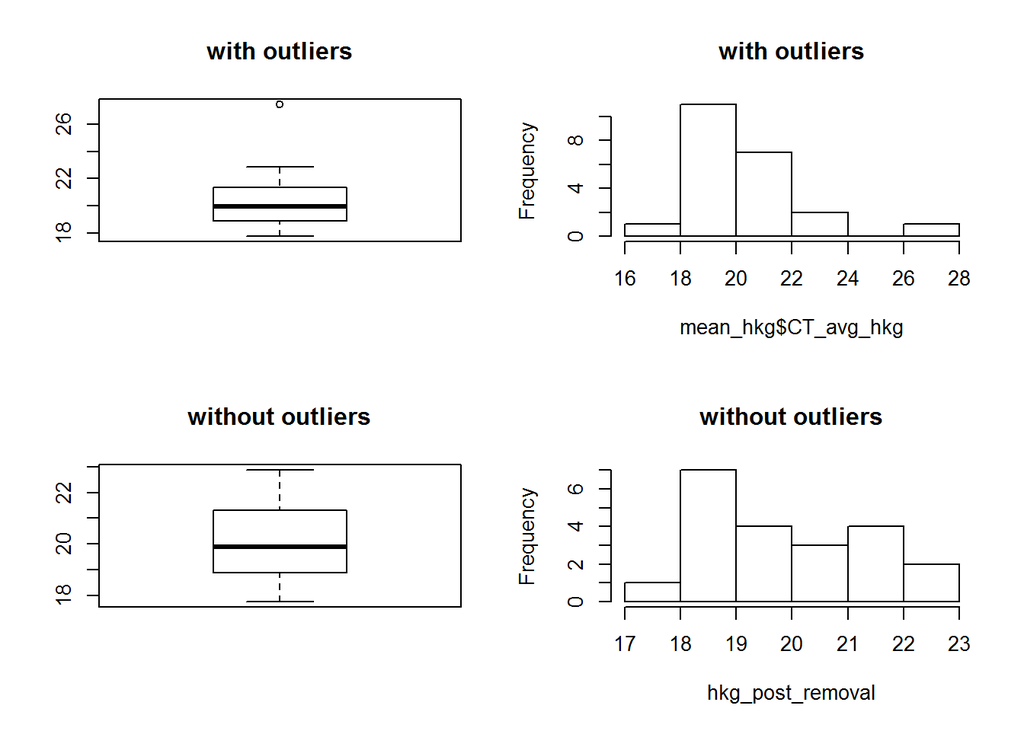

```r
qc_mean_hkg(mean_hkg)
```

### Remove outliers with remove_outliers()

Outliers are defined by boxplots, every sample that is outside 1.5 * IQR is regarded as an outliers and can skew analysis of that data. Therefore, we remove these with the function remove_outliers().

```r
mean_hkg$CT_avg_hkg <- remove_outliers(mean_hkg$CT_avg_hkg)
```

# Delta CT

When quality control is done we can normalize over housekeeping genes. So far this package can calculate Delta CT and Relative expression compared to housekeeping genes. Functions calculating fold change will be incorporated soon.

## Calculate Delta CT with calculate_DCT()

The function calculate_DCT calculates Delta CT and relative expression. Make sure to select your annotation columns that are important for plotting! Fill them in under the cols argument of calculate_DCT(). In this example we selected Cell_type, “Condition” and “Mouse”.

```r
calculate_DCT(endog, mean_hkg, cols = c("Cell_type", "Condition", "Mouse"))
```

## Plot Delta CT

### All genes with plot_scatter()

Make a summary plot of the Delta CT values of all genes and samples together. Therefore, you need to fill in the x.var, y.var and col.var variable in function plot_scatter(). As **x.var** we use *Cell_type* to plot the different cell types over the x axis, **y.var** is *DCt* to plot Delta CT values on the y axis and **col.var** is *Condition* this is because we are comparing between healthy and dystrohpic cells. The function automatically makes a plot per *Gene* in the data set.

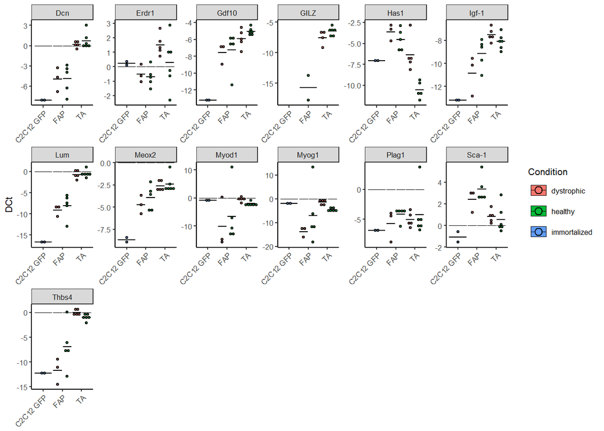

```r
plot_scatter(endog, x.var = "Cell_type", y.var = "DCt", col.var = "Condition")
```

### Select a gene with plot_scatter_per_gene()

You can also plot a specific gene with plot_scatter_per_gene(), you can select the *Gene* under the variable **gene**.

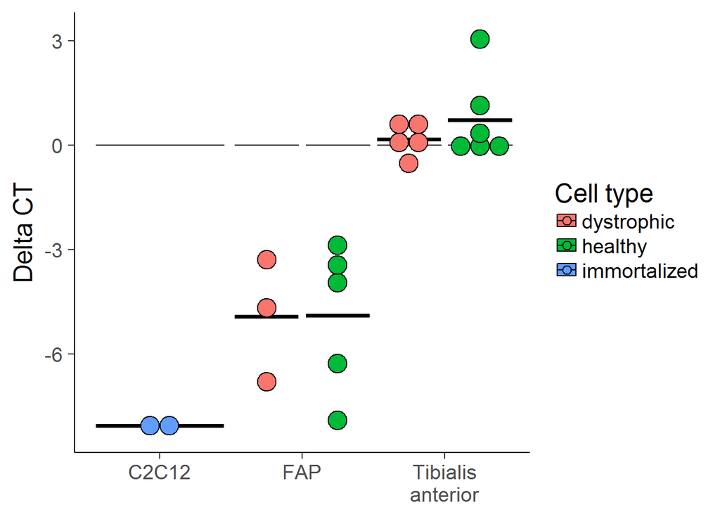

```r
plot_scatter_per_gene(endog, "Dcn", x.var = "Cell_type", y.var = "DCt", col.var = "Condition", theme = 18) +
  labs(y = "Delta CT") +
  scale_fill_discrete(name = "Cell type") +
  scale_x_discrete(labels = c("C2C12 GFP" = "C2C12", "FAP" = "FAP", "TA" = "Tibialis\nanterior"))
```

## Plot relative expression

We can also plot the relative expression towards the housekeeping genes. We generate the same plots as under Delta CT. The only difference is that we use rel_expr as argument for **y.var**.

### All genes with plot_scatter()

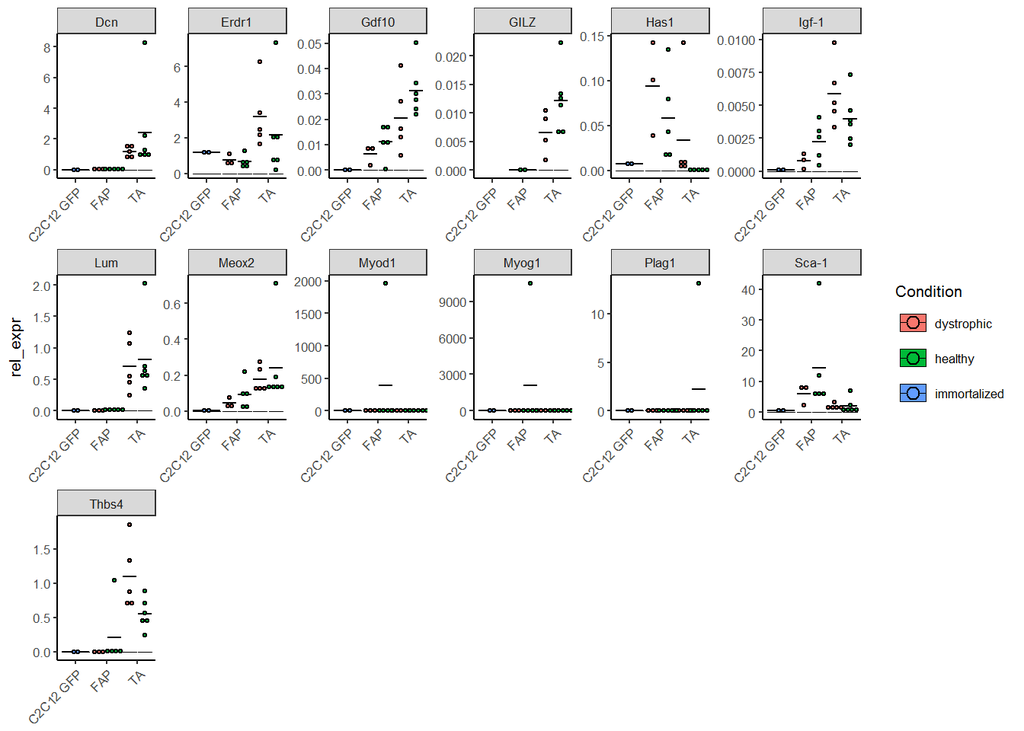

```r
plot_scatter(endog, x.var = "Cell_type", y.var = "rel_expr", col.var = "Condition")
```

### Select a gene with plot_scatter_per_gene()

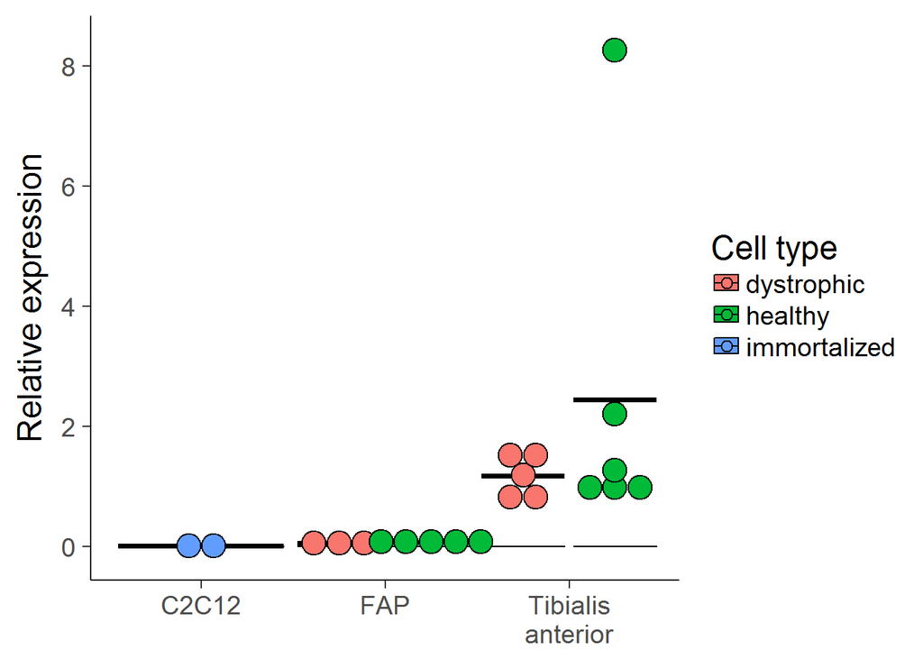

```r
plot_scatter_per_gene(endog, "Dcn", x.var = "Cell_type", y.var = "rel_expr", col.var = "Condition", theme = 18) +
  labs(y = "Relative expression") +
  scale_fill_discrete(name = "Cell type") +
  scale_x_discrete(labels = c("C2C12 GFP" = "C2C12", "FAP" = "FAP", "TA" = "Tibialis\nanterior"))
```